# Part2_RegressionA_Linear_models

Quincey Niu

2023-04-23

## Load packages

```r
library(tidyverse)
library(caret)
```

## Read data

```r
df <- readr::read_csv("paint_project_train_data.csv", col_names = TRUE)
```

### Regression task

```r
dfii <- df %>%
  mutate(y = boot::logit( (response - 0) / (100 - 0) ) ) %>%
  select(R, G, B,
         Lightness, Saturation, Hue,
         y)

dfii %>% glimpse()
```

```
## Rows: 835
## Columns: 7
## $ R          <dbl> 172, 26, 172, 28, 170, 175, 90, 194, 171, 122, 0, 88, 144, …
## $ G          <dbl> 58, 88, 94, 87, 66, 89, 78, 106, 68, 151, 121, 140, 82, 163…
## $ B          <dbl> 62, 151, 58, 152, 58, 65, 136, 53, 107, 59, 88, 58, 132, 50…
## $ Lightness  <chr> "dark", "dark", "dark", "dark", "dark", "dark", "dark", "da…
## $ Saturation <chr> "bright", "bright", "bright", "bright", "bright", "bright",…
## $ Hue        <dbl> 4, 31, 8, 32, 5, 6, 34, 10, 1, 21, 24, 22, 36, 16, 26, 12, …
## $ y          <dbl> -1.9924302, -2.1972246, -1.6582281, -2.1972246, -2.0907411,…
```

## Fitting models using lm()

Intercept-only model

```r
mod1 <- lm(y ~ 1, data = dfii)
```

Categorical variables only - linear additive

```r
mod2 <- lm(y ~ Lightness + Saturation, data = dfii)
```

Continuous variables only - linear additive

```r
mod3 <- lm(y ~ R + G + B + Hue, data = dfii)
```

All categorical and continuous variables - linear additive

```r
mod4 <- lm(y ~ R + G + B + Lightness + Saturation + Hue, data = dfii)
```

Interaction of categorical inputs with all continuous inputs main effects

```r
#mod5 <- lm(y ~ (Lightness + Saturation) * (R + G + B + Hue), data = dfii)
mod5 <- lm(y ~ Lightness:R + Lightness:G + Lightness:B + Saturation:R + Saturation:G + Saturation:B + Hue:R + Hue:G + Hue:B, data = dfii)
```

```r
#mod6 <- lm(y ~ R * G * B * Lightness * Saturation * Hue, data = dfii)
mod6 <- lm(y ~ R + G + B + Lightness + Saturation + Hue + R:Lightness + R:Saturation + R:Hue + G:Lightness + G:Saturation + G:Hue + B:Lightness + B:Saturation + B:Hue, data = dfii)
```

```r
mod7 <- lm(y ~ Lightness + Saturation + Hue + Lightness:R + Lightness:G + Lightness:B + Saturation:R + Saturation:G + Saturation:B + Hue:R + Hue:G + Hue:B, data = dfii)
```

### Model with basis functions of your choice

using cubic spline basis function for R variable

```r
library(splines)
mod8 <- lm(y ~ ns(R, df = 4) + G + B + Lightness + Saturation + Hue, data = dfii)
```

using exponential transformation for G variable

```r
mod9 <- lm(y ~ R + exp(G) + B + Lightness + Saturation + Hue, data = dfii)
```

using interaction between cubic spline basis function for R variable and Saturation variable

```r
mod10 <- lm(y ~ ns(R, df = 4) + G + B + Lightness + Saturation + Hue + ns(R, df = 4):Saturation, data = dfii)
```

```r
p1 <- broom::glance(mod1)
p2 <- broom::glance(mod2)
p3 <- broom::glance(mod3)
p4 <- broom::glance(mod4)
p5 <- broom::glance(mod5)
p6 <- broom::glance(mod6)
p7 <- broom::glance(mod7)
p8 <- broom::glance(mod8)
p9 <- broom::glance(mod9)
p10 <- broom::glance(mod10)
rbind(p1, p2, p3, p4, p5, p6, p7, p8, p9, p10)
```

```
## # A tibble: 10 × 12
##    r.squared adj.r.s…¹  sigma stati…² p.value    df logLik    AIC    BIC devia…³
##        <dbl>     <dbl>  <dbl>   <dbl>   <dbl> <dbl>  <dbl>  <dbl>  <dbl>   <dbl>
##  1     0         0     1.18       NA       NA    NA -1326.  2655.  2665. 1170.
##  2     0.885     0.883 0.405     525.       0    12  -424.   876.   942.  135.
##  3     0.988     0.988 0.129   17235.       0     4   525. -1037. -1009.   13.9
##  4     0.995     0.994 0.0886   9258.       0    16   847. -1659. -1573.    6.42
##  5     0.995     0.995 0.0826   4064.       0    42   920. -1751. -1543.    5.40
##  6     0.998     0.998 0.0575   6422.       0    55  1229. -2344. -2075.    2.57
##  7     0.998     0.998 0.0575   6422.       0    55  1229. -2344. -2075.    2.57
##  8     0.995     0.995 0.0863   8223.       0    19   871. -1700. -1601.    6.07
##  9     0.931     0.930 0.314     692.       0    16  -208.   452.   537.   80.5
## 10     0.996     0.995 0.0800   4234.       0    43   947. -1804. -1591.    5.06
## # … with 2 more variables: df.residual <int>, nobs <int>, and abbreviated
## #   variable names ¹adj.r.squared, ²statistic, ³deviance
```

## Visualize the coefficient summaries for your top 3 models

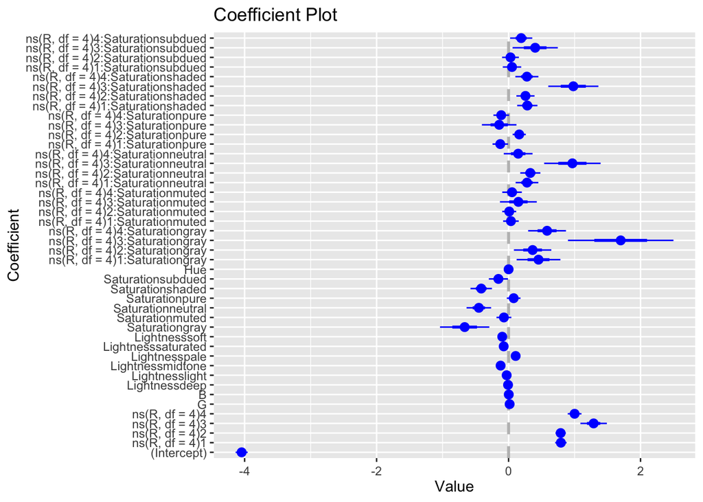

```r
coefplot::coefplot(mod10)
```

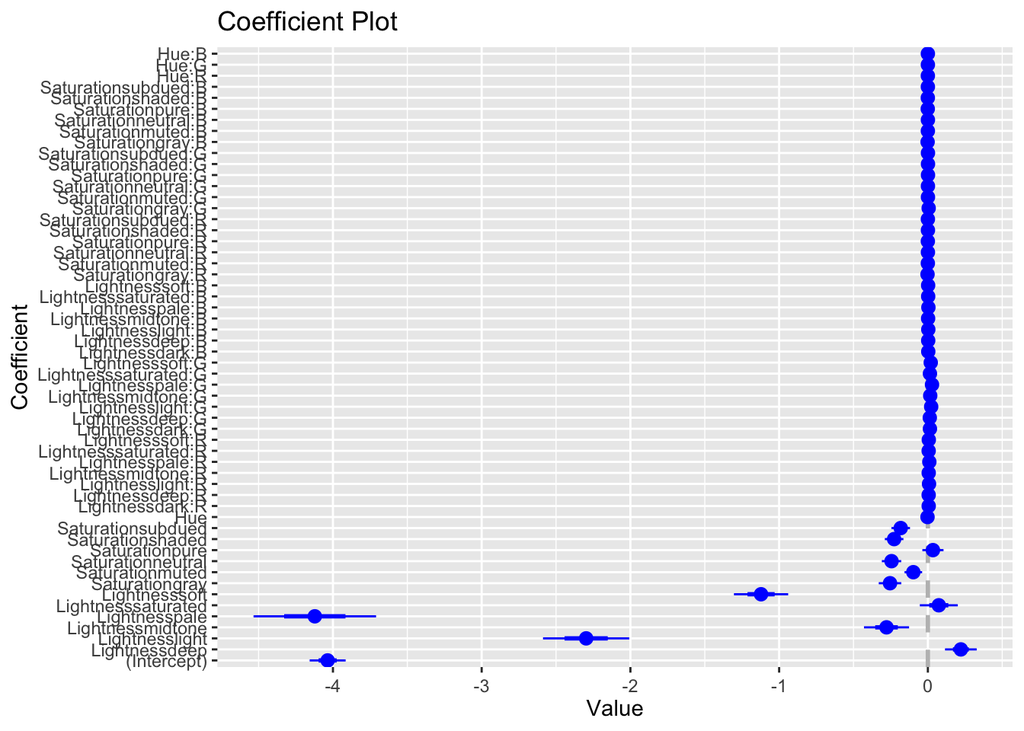

```r
coefplot::coefplot(mod7)
```

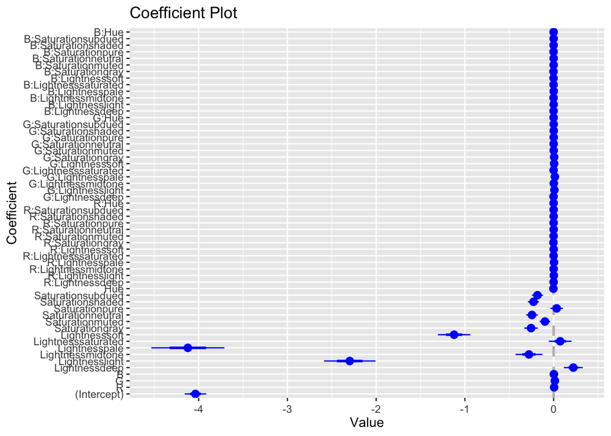

```r
coefplot::coefplot(mod6)
```

Comparing the coefficient summaries of the top 3 models can give us insights into which inputs are important. We can look at the sign and magnitude of the coefficients to determine the direction and strength of the relationship between the inputs and the output. A positive coefficient indicates a positive relationship, while a negative coefficient indicates a negative relationship. The magnitude of the coefficient represents the strength of the relationship.

```r
summary_mod10 <- mod10 %>%
  coefplot::coefplot(sort = "magnitude", plot = FALSE) %>%
  tibble::as_tibble() %>%
  filter((HighOuter > 0 & LowOuter > 0) | (HighOuter < 0 & LowOuter < 0))

head(summary_mod10)
```

```
## # A tibble: 6 × 7
##    Value Coefficient                   HighInner LowInner HighOu…¹ LowOu…² Model
##    <dbl> <fct>                             <dbl>    <dbl>    <dbl>   <dbl> <chr>
## 1 -4.05  (Intercept)                     -4.00     -4.09  -3.95     -4.14  model
## 2 -0.665 Saturationgray                  -0.479    -0.852 -0.292    -1.04  model
## 3 -0.451 Saturationneutral               -0.358    -0.544 -0.265    -0.637 model
## 4 -0.415 Saturationshaded                -0.333    -0.496 -0.252    -0.577 model
## 5 -0.154 Saturationsubdued               -0.0816   -0.226 -0.00926  -0.299 model
## 6 -0.126 ns(R, df = 4)1:Saturationpure   -0.0676   -0.185 -0.00902  -0.243 model
## # … with abbreviated variable names ¹HighOuter, ²LowOuter
```

Lightness, Saturation seem important.